# Predicting Used Cars Prices

Predicting used cars prices is one of the classic problems of machine learning models. In this project, we are going to tacke this problem using a dataset from Kaggle. This data set is quite challenging because on the one hand it is has about 440 thousand of rows, and on the other hand it has a lot of categorical data, which makes the task of predicting a continuous variable (the price of the car) a bit difficult.

The data can be found here:

https://www.kaggle.com/austinreese/craigslist-carstrucks-data

```python
import numpy as np
import pandas as pd
import matplotlib.pyplot as plt
import seaborn as sns
```

```python
from sklearn.model_selection import train_test_split
from sklearn.compose import ColumnTransformer
from sklearn.pipeline import Pipeline
from sklearn.preprocessing import MinMaxScaler
from sklearn.impute import SimpleImputer
from sklearn.preprocessing import OneHotEncoder
from sklearn.model_selection import cross_val_score
from sklearn.model_selection import GridSearchCV

from sklearn.linear_model import LinearRegression
from sklearn.tree import DecisionTreeRegressor
from sklearn.ensemble import RandomForestRegressor
from sklearn.metrics import mean_squared_error

from scipy.stats import zscore
from statistics import mode
from statsmodels.formula.api import ols
```

```python
vehicles_original = pd.read_csv('vehicles.csv')
```

```python
vehicles_original.head(3)
```

|  | id | url | region | region_url | price | year | manufacturer | model | condition | cylinders | ... | drive | size | type | paint_color | image_url | description | county | state | lat | long |
| --- | --- | --- | --- | --- | --- | --- | --- | --- | --- | --- | --- | --- | --- | --- | --- | --- | --- | --- | --- | --- | --- |
| 0 | 7307730503 | https://auburn.craigslist.org/cto/d/opelika-ha... | auburn | https://auburn.craigslist.org | 9500 | 2003.0 | chrysler | town & country | excellent | 6 cylinders | ... | fwd | mid-size | mini-van | blue | https://images.craigslist.org/00w0w_41YO8cHlW3... | 2003 Chrysler Town and Country Handicapped Acc... | NaN | al | 32.614209 | -85.326357 |
| 1 | 7307218858 | https://auburn.craigslist.org/ctd/d/auburn-uni... | auburn | https://auburn.craigslist.org | 28990 | 2018.0 | gmc | acadia sle-2 sport utility | good | 6 cylinders | ... | fwd | NaN | other | white | https://images.craigslist.org/00c0c_kXhBir3Ii6... | Carvana is the safer way to buy a car During t... | NaN | al | 32.590000 | -85.480000 |
| 2 | 7307164168 | https://auburn.craigslist.org/ctd/d/auburn-uni... | auburn | https://auburn.craigslist.org | 16590 | 2013.0 | lincoln | mkz sedan 4d | good | NaN | ... | fwd | NaN | sedan | red | https://images.craigslist.org/00N0N_1xMPvfxRAI... | Carvana is the safer way to buy a car During t... | NaN | al | 32.590000 | -85.480000 |

3 rows × 25 columns

```python
vehicles_original.info()
```

```
<class 'pandas.core.frame.DataFrame'>
RangeIndex: 441396 entries, 0 to 441395
Data columns (total 25 columns):
 #   Column        Non-Null Count   Dtype
---  ------        --------------   -----
 0   id            441396 non-null  int64
 1   url           441396 non-null  object
 2   region        441396 non-null  object
 3   region_url    441396 non-null  object
 4   price         441396 non-null  int64
 5   year          440359 non-null  float64
 6   manufacturer  423019 non-null  object
 7   model         436057 non-null  object
 8   condition     257554 non-null  object
 9   cylinders     253231 non-null  object
```

[output cut: 17 more lines]

By looking at the list of columns, we can anticipate that the following features will not be needed for our analysis:

- id: unique identifier for the ad
- url: url of the ad
- region: if geographical information is required, we can use lat and long
- region_url: region-specific url of the ad
- VIN: Vehicle Identification Number (with the Department of Motor Vehicles).
- image_url: url of the car image associated with the ad
- county: county of the ad.

We will drop the remaining columns right away. We may drop more columns as we go along.

```python
cols_to_drop = ['id','url','region','region_url','VIN','image_url','county']
vehicles = vehicles_original.drop(columns = cols_to_drop, axis = 1)
```

```python
vehicles.head(3)
```

|  | price | year | manufacturer | model | condition | cylinders | fuel | odometer | title_status | transmission | drive | size | type | paint_color | description | state | lat | long |
| --- | --- | --- | --- | --- | --- | --- | --- | --- | --- | --- | --- | --- | --- | --- | --- | --- | --- | --- |
| 0 | 9500 | 2003.0 | chrysler | town & country | excellent | 6 cylinders | gas | 30376.0 | clean | automatic | fwd | mid-size | mini-van | blue | 2003 Chrysler Town and Country Handicapped Acc... | al | 32.614209 | -85.326357 |
| 1 | 28990 | 2018.0 | gmc | acadia sle-2 sport utility | good | 6 cylinders | gas | 20736.0 | clean | other | fwd | NaN | other | white | Carvana is the safer way to buy a car During t... | al | 32.590000 | -85.480000 |
| 2 | 16590 | 2013.0 | lincoln | mkz sedan 4d | good | NaN | gas | 61087.0 | clean | other | fwd | NaN | sedan | red | Carvana is the safer way to buy a car During t... | al | 32.590000 | -85.480000 |

## Numerical variables

**The price variable**

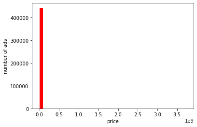

```python
plt.hist(vehicles['price'], bins=40, color='red')
plt.xlabel('price')
plt.ylabel('number of ads')
plt.show()
```

The fact that the x axis extends to 4 billion is clearly wrong. Let's find the minimum and maximum values of the price variable:

```python
print('Minimum price for a car: %d' % vehicles.price.min())
print('Maximum price for a car: %d' % vehicles.price.max())
```

```
Minimum price for a car: 0
Maximum price for a car: 3736928711
```

Let's impose an arbitrary cutoff price of $300,000. The number of records we will lose by dropping cars with a price higher than the cutoff price is:

```python
price_cutoff = 300000
vehicles[vehicles.odometer > price_cutoff].shape[0]
```

```
2800
```

This represents less than 1% of the total number of ads. Let's drop these records now and drop the distribution of prices again:

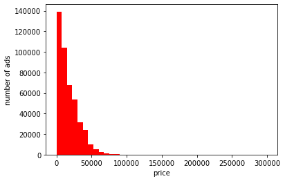

```python
vehicles = vehicles[vehicles.price<price_cutoff]
plt.hist(vehicles['price'], bins=40, color='red')
plt.xlabel('price')
plt.ylabel('number of ads')
plt.show()
```

Let's find out how many cars have a list price of zero dollars:

```python
print('Number of ads with a price of zero dollars: %d' % vehicles[vehicles.price==0].shape[0])
```

```
Number of ads with a price of zero dollars: 34089
```

We shall drop these ads from our data set, because it doesn't make sense to use these records for a model predicting car prices:

```python
vehicles = vehicles[vehicles.price>0]
```

We now turn our attention to the year variable. Let's start by plotting a histogram of this variable:

**The year variable**

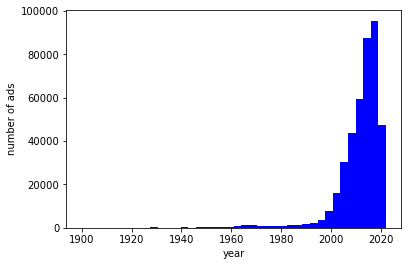

```python
plt.hist(vehicles['year'], bins=40, color='blue')
plt.xlabel('year')
plt.ylabel('number of ads')
plt.show()
```

We see that most ads are for modern cars manufactured after 2000. By examining the minimum and maximum values we find that there were cars advertised on Craiglist that were more than 100 years old:

```python
print('Minimum year for ads: %d' % vehicles.year.min())
print('Maximum year for ads: %d' % vehicles.year.max())
print('Number of ads for 2022 models: %d' % vehicles[vehicles.year==2022].shape[0])
```

```
Minimum year for ads: 1900
Maximum year for ads: 2022
Number of ads for 2022 models: 100
```

Instead of working with the year, we will instead introduce a new variable called car_age which will encode the age of the car:

```python
vehicles['car_age'] = vehicles.year.max() - vehicles.year
vehicles.head(3)
```

|  | price | year | manufacturer | model | condition | cylinders | fuel | odometer | title_status | transmission | drive | size | type | paint_color | description | state | lat | long | car_age |
| --- | --- | --- | --- | --- | --- | --- | --- | --- | --- | --- | --- | --- | --- | --- | --- | --- | --- | --- | --- |
| 0 | 9500 | 2003.0 | chrysler | town & country | excellent | 6 cylinders | gas | 30376.0 | clean | automatic | fwd | mid-size | mini-van | blue | 2003 Chrysler Town and Country Handicapped Acc... | al | 32.614209 | -85.326357 | 19.0 |
| 1 | 28990 | 2018.0 | gmc | acadia sle-2 sport utility | good | 6 cylinders | gas | 20736.0 | clean | other | fwd | NaN | other | white | Carvana is the safer way to buy a car During t... | al | 32.590000 | -85.480000 | 4.0 |
| 2 | 16590 | 2013.0 | lincoln | mkz sedan 4d | good | NaN | gas | 61087.0 | clean | other | fwd | NaN | sedan | red | Carvana is the safer way to buy a car During t... | al | 32.590000 | -85.480000 | 9.0 |

**The odometer variable**

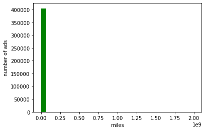

```python
plt.hist(vehicles['odometer'], bins=30, color='green')
plt.xlabel('miles')
plt.ylabel('number of ads')
plt.show()
```

The fact that the x axis extends up to 2 billion miles is not good. Let's look at the min and max values:

```python
print('Min odometer value: %.0f' % vehicles.odometer.min())
print('Max odometer value: %.0f' % vehicles.odometer.max())
```

```
Min odometer value: 0
Max odometer value: 2000799401
```

A reading of 2 billion miles is clearly erroneous. Like we did with the price, we will impose an arbitrary cutoff of 1 million miles on the odometer reading value. Let's see how many records we lose by doing so:

```python
odometer_cutoff = 1000000
vehicles[vehicles.odometer > odometer_cutoff].shape[0]
```

```
486
```

This is not a big number of cars to lose given the size of the dataset (and in any case and odometer reading of more than 1 million miles would be suspect). Let's drop these values and plot a histogram of the remaining records:

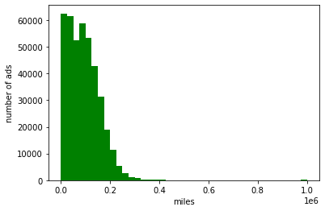

```python
vehicles = vehicles[vehicles.odometer < odometer_cutoff]

plt.hist(vehicles['odometer'], bins=40, color='green')
plt.xlabel('miles')
plt.ylabel('number of ads')
plt.show()
```

Let's examine the number of ads with an odometer reading of zero miles more closely:

```python
vehicles[vehicles.odometer == 0].loc[:,['price','year','odometer','condition', 'title_status','description']].head(10)
```

|  | price | year | odometer | condition | title_status | description |
| --- | --- | --- | --- | --- | --- | --- |
| 852 | 10477 | 2009.0 | 0.0 | NaN | clean | Contemporary Automotive address: 3427 Skyla... |
| 943 | 11980 | 2013.0 | 0.0 | NaN | NaN | 2013 *INFINITI* *G37 Sedan* 4dr Journey RWD - ... |
| 972 | 3980 | 2013.0 | 0.0 | NaN | NaN | 2013 *Kia* *Rio* 4dr Sedan Manual LX - $3,980C... |
| 1618 | 6980 | 2013.0 | 0.0 | NaN | NaN | 2013 *Ford* *Fusion* 4dr Sedan SE FWD - $6,980... |
| 1708 | 6900 | 2016.0 | 0.0 | NaN | clean | Signature Truck CenterAsk for: Craigslist Sale... |
| 4169 | 5850 | 1995.0 | 0.0 | good | clean | I have a 1995 ford f150 in good sound conditio... |
| 8603 | 15995 | 2019.0 | 0.0 | good | clean | 2019 HYUNDAI ACCENT SE Notes from the DealerVi... |
| 9997 | 9500 | 1969.0 | 0.0 | good | clean | 1969 GMC three-quarter ton no dents no Bondo 3... |
| 12502 | 350 | 2021.0 | 0.0 | NaN | clean | NEW GOODYEAR STEER / TRAILER TIRES 16-PLY ONLY... |
| 12505 | 38994 | 1961.0 | 0.0 | excellent | clean | 1961 Ford Galaxie Starliner Fastback 390 w/375... |

The first thing we notice is that an odometer of zero is not necessarily associated with a brand new car (unless we consider that records for cars from 1969 or 1961 are still brand new). Also, by looking at the condition, title status and description columns we can see that these are not necessarily cars that have been in an accident. Let's find how many records with a zero odometer reading thre are:

```python
print('Number of records with an odometer reading of zero: %d' % vehicles[vehicles.odometer == 0].shape[0])
```

```
Number of records with an odometer reading of zero: 1026
```

Given the small total number of these records, we will make the decision to delete them from our dataset:

```python
vehicles = vehicles[vehicles.odometer > 0]
```

We will not utilize the remaining two numerical variables (lat and long) and choose to instead use the state categorical variable for geographical data if needed. The logic behind this is the realization that the price of a car will likely depend on the state, but not on finer granularities of geographic location described by longitude and latitude. We therefore will drop the long and lat columns:

```python
vehicles = vehicles.drop(columns=['long','lat'], axis = 1)
vehicles.head(3)
```

|  | price | year | manufacturer | model | condition | cylinders | fuel | odometer | title_status | transmission | drive | size | type | paint_color | description | state | car_age |
| --- | --- | --- | --- | --- | --- | --- | --- | --- | --- | --- | --- | --- | --- | --- | --- | --- | --- |
| 0 | 9500 | 2003.0 | chrysler | town & country | excellent | 6 cylinders | gas | 30376.0 | clean | automatic | fwd | mid-size | mini-van | blue | 2003 Chrysler Town and Country Handicapped Acc... | al | 19.0 |
| 1 | 28990 | 2018.0 | gmc | acadia sle-2 sport utility | good | 6 cylinders | gas | 20736.0 | clean | other | fwd | NaN | other | white | Carvana is the safer way to buy a car During t... | al | 4.0 |
| 2 | 16590 | 2013.0 | lincoln | mkz sedan 4d | good | NaN | gas | 61087.0 | clean | other | fwd | NaN | sedan | red | Carvana is the safer way to buy a car During t... | al | 9.0 |

Let's now turn our attention to categorical variables. Let's find how many unique values there are for each category:

```python
vehicles.nunique().sort_values()
```

```
transmission         3
drive                3
size                 4
fuel                 5
title_status         6
condition            6
cylinders            8
paint_color         12
type                13
manufacturer        42
state               51
car_age            109
year               109
price            15900
model            28362
odometer        102022
description     342133
dtype: int64
```

We now create a list called cat_features_to_drop where we will record the categorical variables that are candidates to be dropped

```python
cat_features_to_drop = list()
```

**The transmission variable**

```python
vehicles.transmission.value_counts(dropna=False)
```

```
automatic    323798
other         54768
manual        23073
NaN            1585
Name: transmission, dtype: int64
```

A Google search on the types of car transmission reveals that there are three types: automatic, manual and CVT (continuously variable transmission), so we'll assume that this is what the label 'other' represents. We see that there are 1585 NaN values. We shall replace these with automatic, since its the most frequent value (mode) of the distribution:

```python
vehicles = vehicles.fillna(value = {'transmission':'automatic'})
vehicles.transmission.value_counts(dropna=False)
```

```
automatic    325383
other         54768
manual        23073
Name: transmission, dtype: int64
```

**The drive variable**

```python
vehicles.drive.value_counts(dropna=False)
```

```
NaN    121549
4wd    121286
fwd    104631
rwd     55758
Name: drive, dtype: int64
```

It is hard to make an assumption about the NaN values for the drivetrain variable. We can't simply replace these values with fwd or 4wd given how large the number of NaN records is. Instead, we shall keep these as their own category, labelling it as 'unknown':

```python
vehicles = vehicles.fillna(value = {'drive':'unknown'})
vehicles.drive.value_counts(dropna=False)
```

```
unknown    121549
4wd        121286
fwd        104631
rwd         55758
Name: drive, dtype: int64
```

**The size variable**

```python
vehicles['size'].value_counts(dropna=False)
```

```
NaN            287784
full-size       59898
mid-size        33642
compact         18836
sub-compact      3064
Name: size, dtype: int64
```

Given that the majority of values of the variable size is NaN, we shall have to drop this variable from our analysis. Let's append the 'size' feature to the list of categorical features to drop:

```python
cat_features_to_drop.append('size')
print('Categorical features to drop so far: ', cat_features_to_drop)
```

```
Categorical features to drop so far:  ['size']
```

**The fuel variable**

```python
vehicles.fuel.value_counts(dropna=False)
```

```
gas         337202
other        30461
diesel       26673
hybrid        5018
NaN           2141
electric      1729
Name: fuel, dtype: int64
```

We will replace the NaN values of the fuel with gas:

```python
vehicles = vehicles.fillna(value = {'fuel':'gas'})
vehicles.fuel.value_counts(dropna=False)
```

```
gas         339343
other        30461
diesel       26673
hybrid        5018
electric      1729
Name: fuel, dtype: int64
```

**The condition variable**

```python
vehicles.condition.value_counts(dropna=False)
```

```
NaN          158805
good         119101
excellent     96571
like new      20974
fair           6065
new            1158
salvage         550
Name: condition, dtype: int64
```

Here the number of NaN records is too big for us to impute it to any given category, and is too big for us to drop all the corresponding records. We shall keep it as 'unknown':

```python
vehicles = vehicles.fillna(value = {'condition':'unknown'})
vehicles.condition.value_counts(dropna=False)
```

```
unknown      158805
good         119101
excellent     96571
like new      20974
fair           6065
new            1158
salvage         550
Name: condition, dtype: int64
```

**The title status variable**

```python
vehicles.title_status.value_counts(dropna=False)
```

```
clean         381139
NaN             7944
rebuilt         7793
salvage         3943
lien            1508
missing          717
parts only       180
Name: title_status, dtype: int64
```

The number of NaN values is not too big. In the interest of accuracy we'll drop the corresponding records:

```python
vehicles = vehicles.dropna(subset=['title_status'], axis=0)
vehicles.title_status.value_counts(dropna=False)
```

```
clean         381139
rebuilt         7793
salvage         3943
lien            1508
missing          717
parts only       180
Name: title_status, dtype: int64
```

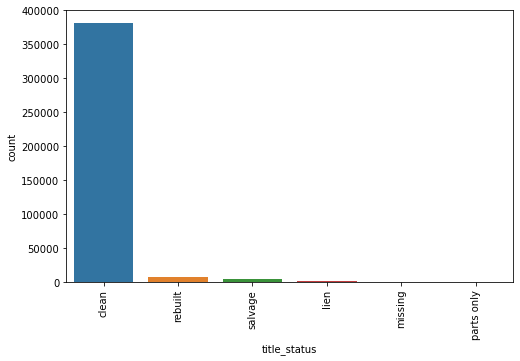

```python
plt.figure(figsize=(8,5))
ax = sns.countplot(x="title_status", data=vehicles, order = vehicles['title_status'].value_counts().index)
plt.xticks(rotation=90)
plt.show()
```

**The cylinders variable**

```python
vehicles.cylinders.value_counts(dropna=False)
```

```
NaN             166835
6 cylinders      85916
4 cylinders      73757
8 cylinders      63979
5 cylinders       1670
10 cylinders      1306
other             1019
3 cylinders        605
12 cylinders       193
Name: cylinders, dtype: int64
```

The number of NaN values is big, and so the cylinders variable is a candidate for being dropped altogether:

```python
cat_features_to_drop.append('cylinders')
print('Categorical features to drop so far: ', cat_features_to_drop)
```

```
Categorical features to drop so far:  ['size', 'cylinders']
```

**The pain color variable**

```python
vehicles.paint_color.value_counts(dropna=False)
```

```
NaN       111219
white      74182
black      61808
silver     41006
blue       30195
red        27616
grey       23605
custom      7506
green       7189
brown       6438
orange      2056
yellow      1811
purple       649
Name: paint_color, dtype: int64
```

It is not clear whether the color will affect the price of a used car. So, let's keep this feature for now and replace the NaN values with unknown:

```python
vehicles = vehicles.fillna(value={'paint_color':'unknown'})
vehicles.paint_color.value_counts(dropna=False)
```

```
unknown    111219
white       74182
black       61808
silver      41006
blue        30195
red         27616
grey        23605
custom       7506
green        7189
brown        6438
orange       2056
yellow       1811
purple        649
Name: paint_color, dtype: int64
```

**The type variable**

```python
vehicles.type.value_counts(dropna=False)
```

```
NaN            86807
sedan          84655
SUV            70607
pickup         34804
truck          30136
other          21879
coupe          17760
hatchback      17508
wagon          10529
van             7900
convertible     7116
mini-van        4590
offroad          561
bus              428
Name: type, dtype: int64
```

We will again keep the NaN's and label them as unknown:

```python
vehicles = vehicles.fillna(value={'type':'unknown'})
vehicles.type.value_counts(dropna=False)
```

```
unknown        86807
sedan          84655
SUV            70607
pickup         34804
truck          30136
other          21879
coupe          17760
hatchback      17508
wagon          10529
van             7900
convertible     7116
mini-van        4590
offroad          561
bus              428
Name: type, dtype: int64
```

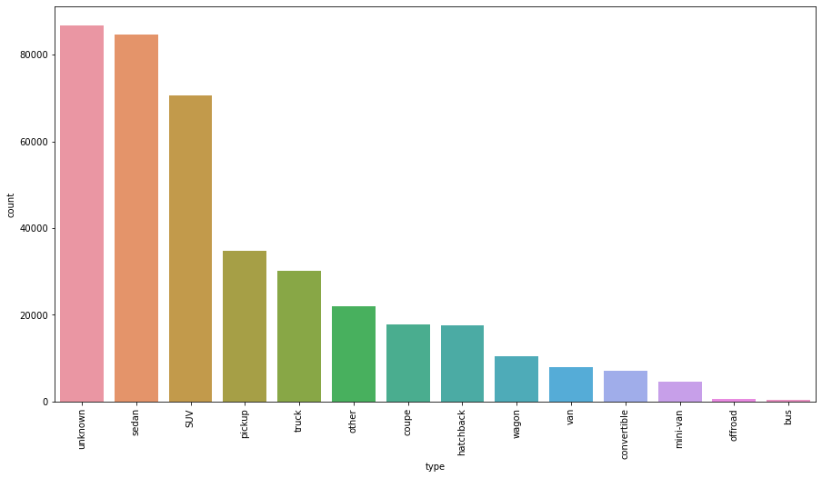

```python
plt.figure(figsize=(15,8))
ax = sns.countplot(x="type", data=vehicles, order = vehicles['type'].value_counts().index)
plt.xticks(rotation=90)
plt.show()
```

**The state variable**

```python
vehicles.state.unique()
```

```
array(['al', 'ak', 'az', 'ar', 'ca', 'co', 'ct', 'dc', 'de', 'fl', 'ga',
       'hi', 'id', 'il', 'in', 'ia', 'ks', 'ky', 'la', 'me', 'md', 'ma',
       'mi', 'mn', 'ms', 'mo', 'mt', 'nc', 'ne', 'nv', 'nj', 'nm', 'ny',
       'nh', 'nd', 'oh', 'ok', 'or', 'pa', 'ri', 'sc', 'sd', 'tn', 'tx',
       'ut', 'vt', 'va', 'wa', 'wv', 'wi', 'wy'], dtype=object)
```

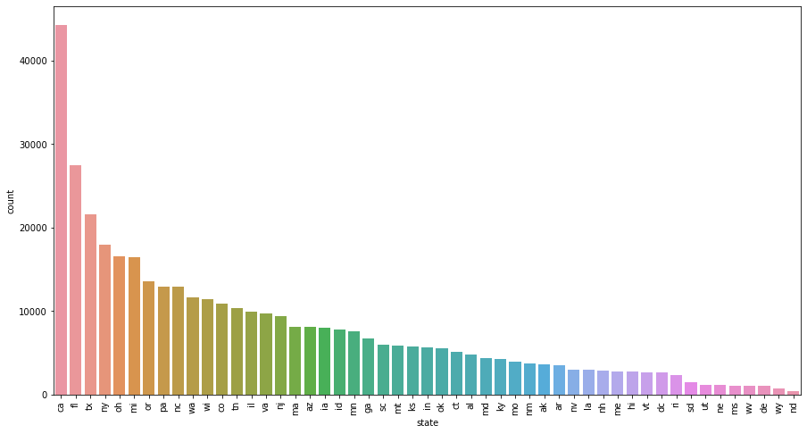

```python
plt.figure(figsize=(15,8))
ax = sns.countplot(x='state', data=vehicles, order = vehicles['state'].value_counts().index)
plt.xticks(rotation=90)
plt.show()
```

Confirming that the state column doesn't include any NaN values:

```python
vehicles.state.isna().sum()
```

```
0
```

**The manufacturer variable**

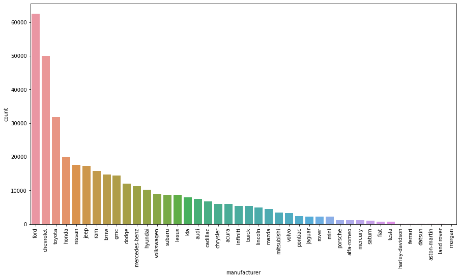

```python
plt.figure(figsize=(15,8))
ax = sns.countplot(x="manufacturer", data=vehicles, order = vehicles['manufacturer'].value_counts().index)
plt.xticks(rotation=90)
plt.show()
```

The number of NaN's (16120) is not too large. In the interest of accuracy, we shall drop all the rows that have NaN values in the manufacturer column:

```python
vehicles = vehicles.dropna(subset=['manufacturer'], axis=0)
print('Number of NaNs in the manufacturer column after cleaning: ', vehicles.manufacturer.isna().sum())
```

```
Number of NaNs in the manufacturer column after cleaning:  0
```

**The model variable**

Let's find the number of unique values in the model column:

```python
vehicles.model.nunique()
```

```
21644
```

This value being too large, it makes no sense to regress on the model variable. However, we will keep this column for now just in case.

**The description variable**

```python
vehicles.description.nunique()
```

```
321884
```

Again, we will keep this variable for now just in case.

We now are in a position where we can drop the categorical variables in the cat_features_to_drop list:

```python
vehicles = vehicles.drop(columns=cat_features_to_drop, axis=1)
```

```python
vehicles.info()
```

```
<class 'pandas.core.frame.DataFrame'>
Int64Index: 379160 entries, 0 to 441395
Data columns (total 15 columns):
 #   Column        Non-Null Count   Dtype
---  ------        --------------   -----
 0   price         379160 non-null  int64
 1   year          379159 non-null  float64
 2   manufacturer  379160 non-null  object
 3   model         374447 non-null  object
 4   condition     379160 non-null  object
 5   fuel          379160 non-null  object
 6   odometer      379160 non-null  float64
 7   title_status  379160 non-null  object
 8   transmission  379160 non-null  object
 9   drive         379160 non-null  object
 10  type          379160 non-null  object
 11  paint_color   379160 non-null  object
 12  description   379158 non-null  object
 13  state         379160 non-null  object
 14  car_age       379159 non-null  float64
dtypes: float64(3), int64(1), object(11)
memory usage: 46.3+ MB
```

Here is the list of columns of our data frame so far:

```python
list_columns = ['price','year','manufacturer','model','condition','fuel','odometer','title_status','transmission','drive',\
             'type','paint_color','description','state','car_age']
```

## More EDA

Let's probe if there are any correlation between price and the other two numerical variables of interest, odometer and car age by computing the correlation matrix:

```python
correlation_matrix = vehicles.corr()
correlation_matrix
```

|  | price | year | odometer | car_age |
| --- | --- | --- | --- | --- |
| price | 1.000000 | 0.345926 | -0.474380 | -0.345926 |
| year | 0.345926 | 1.000000 | -0.343078 | -1.000000 |
| odometer | -0.474380 | -0.343078 | 1.000000 | 0.343078 |
| car_age | -0.345926 | -1.000000 | 0.343078 | 1.000000 |

**Findings:**

- There is a negative correlation of -0.47 between odometer and price, which makes sense: cars with more mileage tend to cost less.
- There is also a negative correlation of -0.35 between the car age and price, which also makes sense: older cars tend to cost less.
- On a side note: there is a positive correlation of 0.34 between the car age and the odometer: older cars tend to have more mileage.

```python
mean_price_per_manuf = vehicles.groupby('manufacturer').mean()['price'].sort_values()

mean_price_per_manuf
```

```
manufacturer
saturn               4399.170190
mercury              5740.269266
pontiac              9711.309340
fiat                 9813.562315
land rover           9871.666667
honda               10892.545014
mazda               11000.666516
hyundai             11943.380752
nissan              12083.422522
volkswagen          12199.978519
kia                 12295.194066
chrysler            12373.285978
mini                12870.910849
datsun              12885.882353
subaru              13210.017461
harley-davidson     13732.285714
dodge               14727.586164
mitsubishi          15528.946636
toyota              15948.607242
buick               16863.208515
volvo               18313.129451
chevrolet           19297.637629
jeep                19451.632527
ford                20361.971446
bmw                 20992.852517
lexus               21317.897166
cadillac            21337.860143
infiniti            21507.505616
acura               21748.845198
lincoln             22227.185458
mercedes-benz       23234.283869
gmc                 24529.474920
audi                25981.033910
jaguar              28848.194357
rover               28992.752914
ram                 29544.491761
alfa-romeo          29935.628774
morgan              32750.000000
porsche             35426.472245
tesla               43199.817620
aston-martin        79575.590909
ferrari            141136.894737
Name: price, dtype: float64
```

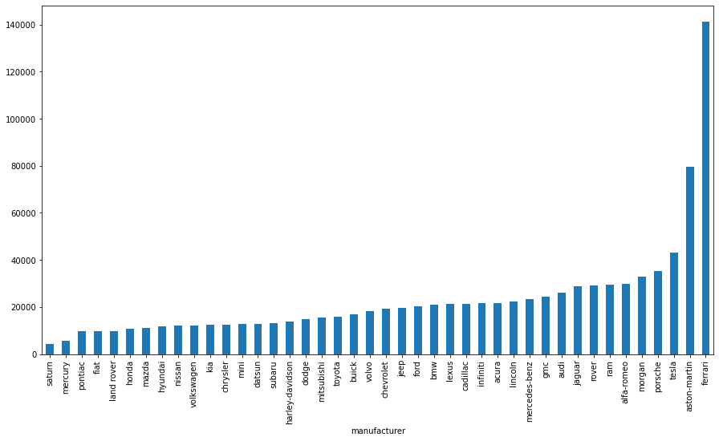

```python
plt.figure(figsize=(15,8))
mean_price_per_manuf.plot(kind='bar')
plt.xticks(rotation=90)
plt.show()
```

**Findings:**

- Used car prices for most consumer brands are in the range of 10-20K
- Some luxury brands have an average price of over 40K.

Now, let's make a boxplot of the price of the cars for each manufacturer:

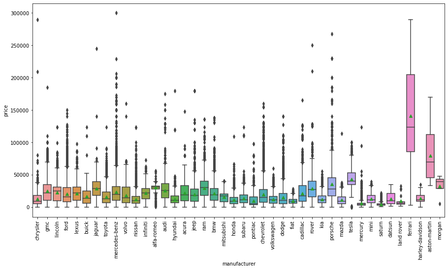

```python
plt.figure(figsize=(15,8))
sns.boxplot(x='manufacturer',y='price', data=vehicles, showmeans=True)
plt.xticks(rotation=90)
plt.show()
```

We see that most manufacturers have many ads with prices that lie in the outlier region. Let's write a custome function to try to remove these outliers from our data.

```python
def IQR(dist):
    # This is the interquantile range of a distribution dist
    return np.percentile(dist,75) - np.percentile(dist,25)

def upper_cutoff(dist):
    # This is the upper cutoff of a distribution dist
    # byond which a data point is considered to be an outlier

    return np.percentile(dist, 75) + 1.5*IQR(dist)

def remove_price_outliers(manufacturer):

    # First, isolate the price column corresponding to a given manufacturer
    df = vehicles[vehicles['manufacturer']==manufacturer].loc[:,['price']]

    # This is to detect the outliers using the z-score
    # z_scores = zscore(df)
    # abs_z_scores = np.abs(z_scores)
    # filtered_entries = (abs_z_scores < 2)

    # This is the upper cutoff to detect outliers
    cutoff = upper_cutoff(df)

    # Create a filter
    filtered_entries = (df['price'] < cutoff)

    # Apply the filer
    df = df[filtered_entries]

    return df
```

## Example analysis for a single manufacturer

```python
# Set the manufacturer
manufacturer = 'ford'

# Create a restricted dataframe where the price column has no outliers
price_without_outliers_df = remove_price_outliers(manufacturer)
price_without_outliers_df.head(3)
```

|  | price |
| --- | --- |
| 5 | 20000 |
| 99 | 5500 |
| 113 | 22500 |

```python
# We merge this dataframe and vehicles by matching the index of the two data frames:
vehicles2 = pd.merge(vehicles, price_without_outliers_df, right_index=True, left_index=True)
vehicles2.head(1)
```

|  | price_x | year | manufacturer | model | condition | fuel | odometer | title_status | transmission | drive | type | paint_color | description | state | car_age | price_y |
| --- | --- | --- | --- | --- | --- | --- | --- | --- | --- | --- | --- | --- | --- | --- | --- | --- |
| 5 | 20000 | 2011.0 | ford | f-150 king ranch 4x4 | good | gas | 101000.0 | clean | automatic | 4wd | pickup | black | 2011 Ford F-150 King Ranch 4x4 with V8. Loaded... | al | 11.0 | 20000 |

Notice how the price column has been relabeled price_x, and a new column price_y has been added to the merged dataframe. We need to drop the price_y column, and relabel price_x as price.

```python
vehicles2.drop('price_y', axis=1, inplace=True)
vehicles2.rename(columns={'price_x':'price'}, inplace=True)
vehicles2.head(1)
```

|  | price | year | manufacturer | model | condition | fuel | odometer | title_status | transmission | drive | type | paint_color | description | state | car_age |
| --- | --- | --- | --- | --- | --- | --- | --- | --- | --- | --- | --- | --- | --- | --- | --- |
| 5 | 20000 | 2011.0 | ford | f-150 king ranch 4x4 | good | gas | 101000.0 | clean | automatic | 4wd | pickup | black | 2011 Ford F-150 King Ranch 4x4 with V8. Loaded... | al | 11.0 |

Let's draw a boxplot of price by manufacturer again and see if the outliers are not longer there:

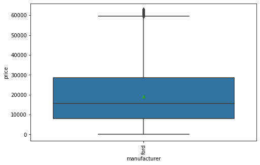

```python
plt.figure(figsize=(8,5))
sns.boxplot(x='manufacturer', y='price', data=vehicles2, showmeans=True)
plt.xticks(rotation=90)
plt.show()
```

The price range for Ford cars has been dramatically reduced: it used to go all the way to 150K, and now it remains in the range of 62K. Most of the outliers have been removed.

Having cleaned the outliers in the price attribute, let's make a first attempt at building a linear regression model to predict the price of cars for this particular model. This will be done next.

## Linear Regression Model

We now want to prepare our data for linear regression. We'll use a pipeline for numerical features (odometer and car_age) where we rescale these two variables to be in the (0,1) range:

```python
num_attribs = ['odometer','car_age']
num_pipeline = Pipeline([
    ('min_max_scaler', MinMaxScaler()),
])
```

For the categorical attributes, we will use a one hot encoder, and wrap a column transformer around the numerical and categorical pipelines:

```python
cat_attribs = ['manufacturer','condition','fuel','title_status','transmission','drive','type','state']
full_pipeline = ColumnTransformer([
    ('num', num_pipeline, num_attribs),
    ('cat', OneHotEncoder(), cat_attribs),
])
```

We now apply our full pipeline to transform the data frame vehicles2 (with data restricted to one manufacturer only):

```python
vehicles_prepared = full_pipeline.fit_transform(vehicles2)
```

The labels are given by the price column of the vehicles2 data frame:

```python
labels = vehicles2['price']
```

Let's define a linear regression model and fit it to the prepared features and associated labels:

```python
lin_reg = LinearRegression()
lin_reg.fit(vehicles_prepared, labels)
```

```
LinearRegression()
```

We now are ready to make some predictions on our full dataset vehicles2:

```python
price_predictions = lin_reg.predict(vehicles_prepared)
```

Let's find the RMSE (Root Mean Squared Error) of our entire vehicles2 dataset:

```python
lin_mse = mean_squared_error(labels, price_predictions)
lin_rmse = np.sqrt(lin_mse)
print("RMSE of the linear regression price predictions for the vehicles2 data set: %.0f" % lin_rmse)
```

```
RMSE of the linear regression price predictions for the vehicles2 data set: 9559
```

Let's compare this RMSE to the median price of cars for this particular manufacturer:

```python
print(lin_rmse/(vehicles2.price.median()))
```

```
0.6167190491133038
```

This result indicates that the RMSE of the predicted prices is about $62\%$ of the median price of cars for this particular manufacturer, which is of course not satisfying. This underlines the difficulty in doing linear regression when most of the features are categorical.

Fortunately, there is a regression method which is well-suited to the situation at hand with many categorical features. This is what we shall use next.

## Random Tree Regression

We start by instantiating a Decision Tree Regressor, and fit it to the prepared data:

```python
tree_reg = DecisionTreeRegressor()
tree_reg.fit(vehicles_prepared, labels)
```

```
DecisionTreeRegressor()
```

We then use our regressor to predict the data:

```python
tree_predictions = tree_reg.predict(vehicles_prepared)
```

Finally, we find the RMSE of our regressor:

```python
tree_mse = mean_squared_error(labels, tree_predictions)
tree_rmse = np.sqrt(tree_mse)
print('RMSE of the random tree regression price predictions for the vehicles2 data set:',tree_rmse)
```

```
RMSE of the random tree regression price predictions for the vehicles2 data set: 548.4015260118789
```

Let's find the ratio of the RMSE to the median price of cars for this particular manufacturer:

```python
print('Ratio of RMSE to median price for this particular manufacturer: %.3f' % (tree_rmse/vehicles2.price.median()))
```

```
Ratio of RMSE to median price for this particular manufacturer: 0.035
```

The ratio of RMSE to the median price is less than 4%, which looks too good to be true! Is our model overfitting? We will peform a 10-fold cross validation on our dataset in order to find out.

```python
scores = cross_val_score(tree_reg, vehicles_prepared, labels, scoring="neg_mean_squared_error", cv=10)
```

```python
tree_rmse_scores = np.sqrt(-scores)
```

```python
def display_scores(scores):
    print("Scores:", scores)
    print("Mean:", scores.mean())
    print("Standard deviation:", scores.std())
```

```python
display_scores(tree_rmse_scores)
```

```
Scores: [8850.29755684 7336.02649513 9058.17698685 7101.75134722 7078.3415761
 7686.79127389 6929.3488661  8875.33822555 8053.81448849 7433.5106982 ]
Mean: 7840.339751437035
Standard deviation: 775.8487560525316
```

```python
8000/vehicles2.price.median()
```

```
0.5161290322580645
```

Now the ratio of RMSE to the median price is of order of $50\%$ again.

## Random Forest Regression

In search for better results, we now apply a random forest regressor to our data, and we furthermore want to automate hyperparameter tuning using grid search CV.

```python
param_grid = [
{'n_estimators': [3, 10, 30], 'max_features': [2, 4, 6, 8]},
{'bootstrap': [False], 'n_estimators': [3, 10], 'max_features': [2, 3, 4]},
]

forest_reg = RandomForestRegressor()

grid_search = GridSearchCV(forest_reg, param_grid, cv=5, scoring='neg_mean_squared_error', return_train_score=True)

grid_search.fit(vehicles_prepared, labels)
```

```
GridSearchCV(cv=5, estimator=RandomForestRegressor(),
             param_grid=[{'max_features': [2, 4, 6, 8],
                          'n_estimators': [3, 10, 30]},
                         {'bootstrap': [False], 'max_features': [2, 3, 4],
                          'n_estimators': [3, 10]}],
             return_train_score=True, scoring='neg_mean_squared_error')
```

Let's print the best parameters of our grid search:

```python
grid_search.best_params_
```

```
{'max_features': 8, 'n_estimators': 30}
```

Let's also display the best estimator:

```python
grid_search.best_estimator_
```

```
RandomForestRegressor(max_features=8, n_estimators=30)
```

Here is a summary of the results of the grid search:

```python
cv_results = grid_search.cv_results_
```

```python
for mean_score, params in zip(cv_results["mean_test_score"], cv_results["params"]):
    print(np.sqrt(-mean_score), params)
```

```
8130.974210367224 {'max_features': 2, 'n_estimators': 3}
7312.058836862509 {'max_features': 2, 'n_estimators': 10}
6927.488208568886 {'max_features': 2, 'n_estimators': 30}
7853.977530916049 {'max_features': 4, 'n_estimators': 3}
7138.835264219785 {'max_features': 4, 'n_estimators': 10}
6836.563183772283 {'max_features': 4, 'n_estimators': 30}
7680.3768969969515 {'max_features': 6, 'n_estimators': 3}
7006.522775438272 {'max_features': 6, 'n_estimators': 10}
6745.757097708801 {'max_features': 6, 'n_estimators': 30}
7524.960782451974 {'max_features': 8, 'n_estimators': 3}
6964.248854775514 {'max_features': 8, 'n_estimators': 10}
6698.108440442247 {'max_features': 8, 'n_estimators': 30}
7974.345396418558 {'bootstrap': False, 'max_features': 2, 'n_estimators': 3}
7227.746119347033 {'bootstrap': False, 'max_features': 2, 'n_estimators': 10}
7933.333096093701 {'bootstrap': False, 'max_features': 3, 'n_estimators': 3}
7113.285858639679 {'bootstrap': False, 'max_features': 3, 'n_estimators': 10}
7791.846350764919 {'bootstrap': False, 'max_features': 4, 'n_estimators': 3}
7062.5306581154655 {'bootstrap': False, 'max_features': 4, 'n_estimators': 10}
```

As can be seen, the use of a random forest regressor didn't bring about a lot of improvement in the performance of the regression analysis, even though we used grid search CV.

One possible reason is that one car manufacturer can have many models with varying prices, and grouping together all these models brings about results that are not very accurate. In the following, we shall specialize to one specific model, and see if that helps us improve the model performance.

## Specializing to one model of cars

Let's try to specialize our linear regression to one specific model and see if we are going to get better results. We shall start by cleaning the model attribute, and first drop all NA values since we now are going to use this feature in our model.

```python
vehicles2 = vehicles2.dropna(subset=['model'], axis=0)
```

We now are going to try to correct the typos in the spelling of the different models, and also adopt a unified model name in case the model has a prefix or postfix or is part of a sentence:

```python
print('Number of unique features in the model column before cleaning the data: ', vehicles2.model.nunique())

vehicles2['model'] = vehicles2['model'].str.lower()

vehicles2["model"] = vehicles2["model"].apply(lambda x: 'f-100' if ('f100' in x or 'f-100' in x or 'f 100' in x) else x)
vehicles2["model"] = vehicles2["model"].apply(lambda x: 'f-150' if ('f150' in x or 'f-150' in x or 'f 150' in x) else x)
vehicles2["model"] = vehicles2["model"].apply(lambda x: 'f-250' if ('f250' in x or 'f-250' in x or 'f 250' in x) else x)
vehicles2["model"] = vehicles2["model"].apply(lambda x: 'f-350' if ('f350' in x or 'f-350' in x or 'f 350' in x) else x)
vehicles2["model"] = vehicles2["model"].apply(lambda x: 'f-450' if ('f450' in x or 'f-450' in x or 'f 450' in x) else x)
vehicles2["model"] = vehicles2["model"].apply(lambda x: 'f-550' if ('f550' in x or 'f-550' in x or 'f 550' in x) else x)
vehicles2["model"] = vehicles2["model"].apply(lambda x: 'f-650' if ('f650' in x or 'f-650' in x or 'f 650' in x) else x)
vehicles2["model"] = vehicles2["model"].apply(lambda x: 'f-750' if ('f750' in x or 'f-750' in x or 'f 750' in x) else x)

vehicles2["model"] = vehicles2["model"].apply(lambda x: 'e100' if ('e100' in x or 'e-100' in x or 'e 100' in x) else x)
vehicles2["model"] = vehicles2["model"].apply(lambda x: 'e150' if ('e150' in x or 'e-150' in x or 'e 150' in x) else x)
vehicles2["model"] = vehicles2["model"].apply(lambda x: 'e250' if ('e250' in x or 'e-250' in x or 'e 250' in x) else x)
vehicles2["model"] = vehicles2["model"].apply(lambda x: 'e350' if ('e350' in x or 'e-350' in x or 'e 350' in x) else x)
vehicles2["model"] = vehicles2["model"].apply(lambda x: 'e450' if ('e450' in x or 'e-450' in x or 'e 450' in x) else x)
vehicles2["model"] = vehicles2["model"].apply(lambda x: 'e550' if ('e550' in x or 'e-550' in x or 'e 550' in x) else x)
vehicles2["model"] = vehicles2["model"].apply(lambda x: 'e650' if ('e650' in x or 'e-650' in x or 'e 650' in x) else x)
vehicles2["model"] = vehicles2["model"].apply(lambda x: 'e750' if ('e750' in x or 'e-750' in x or 'e 750' in x) else x)

vehicles2["model"] = vehicles2['model'].apply(lambda x: 'taurus' if 'taurus' in x else x)
vehicles2['model'] = vehicles2['model'].apply(lambda x: 'focus' if 'focus' in x else x)
vehicles2['model'] = vehicles2['model'].apply(lambda x: 'edge' if 'edge' in x else x)
vehicles2['model'] = vehicles2['model'].apply(lambda x: 'transit' if ('transit' in x) else x)
vehicles2['model'] = vehicles2['model'].apply(lambda x: 'explorer' if ('explorer' in x) else x)
vehicles2['model'] = vehicles2['model'].apply(lambda x: 'fusion' if 'fusion' in x else x)
vehicles2['model'] = vehicles2['model'].apply(lambda x: 'victoria' if 'victoria' in x else x)
vehicles2['model'] = vehicles2['model'].apply(lambda x: 'ranger' if 'ranger' in x else x)
vehicles2['model'] = vehicles2['model'].apply(lambda x: 'ranchero' if ('fairlane' in x or 'ranchero' in x) else x)
vehicles2['model'] = vehicles2['model'].apply(lambda x: 'cutaway' if 'cutaway' in x else x)
vehicles2['model'] = vehicles2['model'].apply(lambda x: 'van' if ('cargo' in x or 'van' in x) else x)
vehicles2['model'] = vehicles2['model'].apply(lambda x: 'thunderbird' if 'thunderbird' in x else x)
vehicles2['model'] = vehicles2['model'].apply(lambda x: 'mustang' if 'mustang' in x else x)
vehicles2['model'] = vehicles2['model'].apply(lambda x: 'expedition' if 'expedition' in x else x)
vehicles2['model'] = vehicles2['model'].apply(lambda x: 'excursion' if 'excursion' in x else x)
vehicles2['model'] = vehicles2['model'].apply(lambda x: 'titanium' if 'titanium' in x else x)
vehicles2['model'] = vehicles2['model'].apply(lambda x: 'escape' if 'escape' in x else x)
vehicles2['model'] = vehicles2['model'].apply(lambda x: 'sport-trac' if 'sport trac' in x else x)
vehicles2['model'] = vehicles2['model'].apply(lambda x: 'fiesta' if 'fiesta' in x else x)
vehicles2['model'] = vehicles2['model'].apply(lambda x: 'c-max' if 'c-max' in x else x)
vehicles2['model'] = vehicles2['model'].apply(lambda x: 'econoline' if 'econoline' in x else x)
vehicles2['model'] = vehicles2['model'].apply(lambda x: 'bronco' if 'bronco' in x else x)
vehicles2['model'] = vehicles2['model'].apply(lambda x: 'freestyle' if 'freestyle' in x else x)
vehicles2['model'] = vehicles2['model'].apply(lambda x: 'torino' if 'torino' in x else x)
vehicles2['model'] = vehicles2['model'].apply(lambda x: 'coupe' if 'coupe' in x else x)


print('Number of unique features in the model column after cleaning the data: ', vehicles2.model.nunique())
```

```
Number of unique features in the model column before cleaning the data:  3417
Number of unique features in the model column after cleaning the data:  562
```

```python
# Print the top 10 models:
vehicles2.model.value_counts()[0:10]
```

```
f-150       13842
f-250        5935
f-350        4156
escape       3873
mustang      3758
explorer     3546
focus        3330
fusion       3270
edge         2197
transit      2059
Name: model, dtype: int64
```

There is enough data for the F-150 to allow us to do a linear regression. We shall call vehicles3 the data frame containing only the single model of interest we will be looking at.

```python
vehicles3 = vehicles2[vehicles2.model == 'f-150']
vehicles3.head(3)
```

|  | price | year | manufacturer | model | condition | fuel | odometer | title_status | transmission | drive | type | paint_color | description | state | car_age |
| --- | --- | --- | --- | --- | --- | --- | --- | --- | --- | --- | --- | --- | --- | --- | --- |
| 5 | 20000 | 2011.0 | ford | f-150 | good | gas | 101000.0 | clean | automatic | 4wd | pickup | black | 2011 Ford F-150 King Ranch 4x4 with V8. Loaded... | al | 11.0 |
| 161 | 6800 | 2008.0 | ford | f-150 | excellent | gas | 202000.0 | clean | automatic | 4wd | pickup | unknown | 2008 Ford F-150 4x4. One owner fleet maintaine... | al | 14.0 |
| 166 | 3750 | 1978.0 | ford | f-150 | good | gas | 123456.0 | clean | automatic | rwd | truck | unknown | For Sale 1978 Ford F150 351 M 400 Engine, Aut... | al | 44.0 |

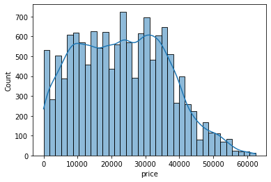

```python
sns.histplot(x='price', data=vehicles3, kde = True)
```

In order to improve the accuracy of our model, we make the decision to drop all rows of the vehicles3 data frame where the price is less than 300 dollars (this cutoff being the going price of a salvaged car sold for scrap parts).

```python
vehicles3 = vehicles3[vehicles3.price > 300]
```

Let's plot a histogram of the odometer attribute:

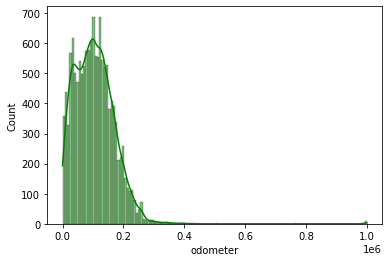

```python
sns.histplot(x='odometer', data=vehicles3, kde = True, color='green')
```

There are a few outliers with high values of the odometer reading. We will remove these further below.

Lastly, we are going to plot a histogram of the car_age variable:

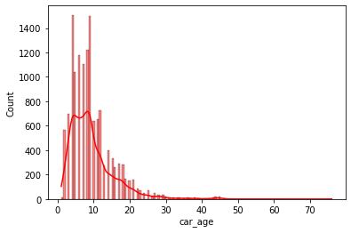

```python
sns.histplot(x='car_age', data=vehicles3, kde = True, color='red')
```

We shall remove the outliers in the car_age attribute a little further below. At this point, we shall keep the outliers in the odometer and car_age attributes and attempt a linear regression model.

### Linear Regression Model

```python
model_prepared = full_pipeline.fit_transform(vehicles3)
```

```python
model_labels = vehicles3.price
```

```python
lin_reg = LinearRegression()
lin_reg.fit(model_prepared, model_labels)
```

```
LinearRegression()
```

```python
price_predictions_model = lin_reg.predict(model_prepared)
```

```python
lin_mse = mean_squared_error(model_labels, price_predictions_model)
lin_rmse = np.sqrt(lin_mse)
print("RMSE of the linear regression price predictions for the vehicles2 data set: %.0f" % lin_rmse)
```

```
RMSE of the linear regression price predictions for the vehicles2 data set: 7828
```

```python
print(lin_rmse/(vehicles3.price.median()))
```

```
0.34034212666105207
```

### Random Tree Regressor

```python
tree_reg_model = DecisionTreeRegressor()
tree_reg_model.fit(model_prepared, model_labels)
```

```
DecisionTreeRegressor()
```

```python
tree_predictions = tree_reg_model.predict(model_prepared)
```

```python
scores = cross_val_score(tree_reg_model, model_prepared, model_labels, scoring="neg_mean_squared_error", cv=10)
```

```python
tree_rmse_scores = np.sqrt(-scores)
```

```python
display_scores(tree_rmse_scores)
```

```
Scores: [8013.16270607 6553.55275089 8625.55210603 8263.08996437 5199.80099859
 5632.72687155 6682.04208877 8719.74124516 7116.06715278 7500.87600269]
Mean: 7230.661188690339
Standard deviation: 1156.0575968843511
```

### Random Forest Regressor with Grid Search CV

```python
param_grid = [
{'n_estimators': [3, 10, 30], 'max_features': [2, 4, 6, 8]},
{'bootstrap': [False], 'n_estimators': [3, 10], 'max_features': [2, 3, 4]},
]

forest_reg_model = RandomForestRegressor()

grid_search_model = GridSearchCV(forest_reg_model, param_grid, cv=5, scoring='neg_mean_squared_error', return_train_score=True)

grid_search_model.fit(model_prepared, model_labels)
```

```
GridSearchCV(cv=5, estimator=RandomForestRegressor(),
             param_grid=[{'max_features': [2, 4, 6, 8],
                          'n_estimators': [3, 10, 30]},
                         {'bootstrap': [False], 'max_features': [2, 3, 4],
                          'n_estimators': [3, 10]}],
             return_train_score=True, scoring='neg_mean_squared_error')
```

```python
grid_search_model.best_params_
```

```
{'max_features': 8, 'n_estimators': 30}
```

```python
grid_search.best_estimator_
```

```
RandomForestRegressor(max_features=8, n_estimators=30)
```

```python
cv_results = grid_search.cv_results_
```

```python
for mean_score, params in zip(cv_results["mean_test_score"], cv_results["params"]):
    print(np.sqrt(-mean_score), params)
```

```
8130.974210367224 {'max_features': 2, 'n_estimators': 3}
7312.058836862509 {'max_features': 2, 'n_estimators': 10}
6927.488208568886 {'max_features': 2, 'n_estimators': 30}
7853.977530916049 {'max_features': 4, 'n_estimators': 3}
7138.835264219785 {'max_features': 4, 'n_estimators': 10}
6836.563183772283 {'max_features': 4, 'n_estimators': 30}
7680.3768969969515 {'max_features': 6, 'n_estimators': 3}
7006.522775438272 {'max_features': 6, 'n_estimators': 10}
6745.757097708801 {'max_features': 6, 'n_estimators': 30}
7524.960782451974 {'max_features': 8, 'n_estimators': 3}
6964.248854775514 {'max_features': 8, 'n_estimators': 10}
6698.108440442247 {'max_features': 8, 'n_estimators': 30}
7974.345396418558 {'bootstrap': False, 'max_features': 2, 'n_estimators': 3}
7227.746119347033 {'bootstrap': False, 'max_features': 2, 'n_estimators': 10}
7933.333096093701 {'bootstrap': False, 'max_features': 3, 'n_estimators': 3}
7113.285858639679 {'bootstrap': False, 'max_features': 3, 'n_estimators': 10}
7791.846350764919 {'bootstrap': False, 'max_features': 4, 'n_estimators': 3}
7062.5306581154655 {'bootstrap': False, 'max_features': 4, 'n_estimators': 10}
```

The results are still not very satisfying. Here we recall that when we cleaned the outliers, we did so for the price column only. Let's follow the same process as we did above and clean the outliers in the odometer and car_age attributes. First, let's plot the outliters in the odometer attribute for the specifc manufacturer and model we are looking at:

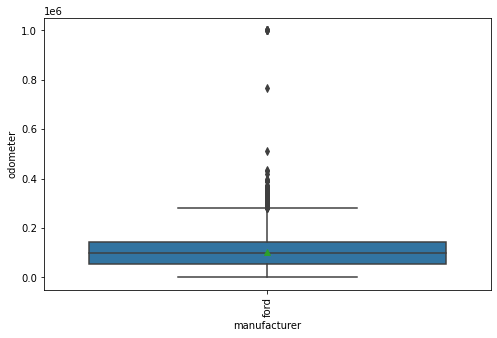

```python
plt.figure(figsize=(8,5))
sns.boxplot(x='manufacturer', y='odometer', data=vehicles3, showmeans=True)
plt.xticks(rotation=90)
plt.show()
```

```python
def remove_odometer_outliers():

    # First, isolate the price column corresponding to a given manufacturer
    df = vehicles3.loc[:,['odometer']]

    # This is to detect the outliers using the z-score
    # z_scores = zscore(df)
    # abs_z_scores = np.abs(z_scores)
    # filtered_entries = (abs_z_scores < 2)

    # This is the upper cutoff to detect outliers
    cutoff = upper_cutoff(df)

    # Create a filter
    filtered_entries = (df['odometer'] < cutoff)

    # Apply the filer
    df = df[filtered_entries]

    return df
```

```python
# Create a restricted dataframe where the odometer column has no outliers
odometer_without_outliers_df = remove_odometer_outliers()
odometer_without_outliers_df.head(3)
```

|  | odometer |
| --- | --- |
| 5 | 101000.0 |
| 161 | 202000.0 |
| 166 | 123456.0 |

```python
# Merge the above dataframe with the vehicles3 dataframe
vehicles4 = pd.merge(vehicles3, odometer_without_outliers_df, right_index=True, left_index=True)
vehicles4.head(1)
```

|  | price | year | manufacturer | model | condition | fuel | odometer_x | title_status | transmission | drive | type | paint_color | description | state | car_age | odometer_y |
| --- | --- | --- | --- | --- | --- | --- | --- | --- | --- | --- | --- | --- | --- | --- | --- | --- |
| 5 | 20000 | 2011.0 | ford | f-150 | good | gas | 101000.0 | clean | automatic | 4wd | pickup | black | 2011 Ford F-150 King Ranch 4x4 with V8. Loaded... | al | 11.0 | 101000.0 |

```python
# Drop the odometer_y column and rename odometer_x -> odometer
vehicles4.drop('odometer_y', axis=1, inplace=True)
vehicles4.rename(columns={'odometer_x':'odometer'}, inplace=True)
vehicles4.head(1)
```

|  | price | year | manufacturer | model | condition | fuel | odometer | title_status | transmission | drive | type | paint_color | description | state | car_age |
| --- | --- | --- | --- | --- | --- | --- | --- | --- | --- | --- | --- | --- | --- | --- | --- |
| 5 | 20000 | 2011.0 | ford | f-150 | good | gas | 101000.0 | clean | automatic | 4wd | pickup | black | 2011 Ford F-150 King Ranch 4x4 with V8. Loaded... | al | 11.0 |

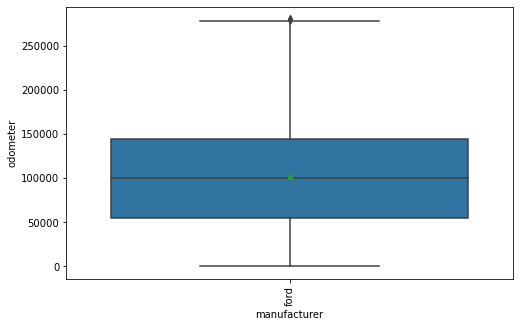

```python
# Draw a boxplot again to make sure there are no outliers:
plt.figure(figsize=(8,5))
sns.boxplot(x='manufacturer', y='odometer', data=vehicles4, showmeans=True)
plt.xticks(rotation=90)
plt.show()
```

**Let's remove the outliers from the car_age attribute**

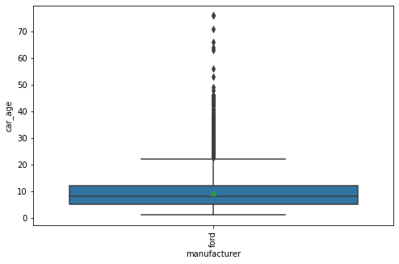

```python
# Draw a boxplot of the car_age attribute before we clean the outliers
plt.figure(figsize=(8,5))
sns.boxplot(x='manufacturer', y='car_age', data=vehicles3, showmeans=True)
plt.xticks(rotation=90)
plt.show()
```

```python
def remove_car_age_outliers():

    # First, isolate the price column corresponding to a given manufacturer
    df = vehicles4.loc[:,['car_age']]

    # This is to detect the outliers using the z-score
    # z_scores = zscore(df)
    # abs_z_scores = np.abs(z_scores)
    # filtered_entries = (abs_z_scores < 2)

    # This is the upper cutoff to detect outliers
    cutoff = upper_cutoff(df)

    # Create a filter
    filtered_entries = (df['car_age'] < cutoff)

    # Apply the filer
    df = df[filtered_entries]

    return df
```

```python
# Create a restricted dataframe where the car_age column has no outliers
age_without_outliers_df = remove_car_age_outliers()
age_without_outliers_df.head(3)
```

|  | car_age |
| --- | --- |
| 5 | 11.0 |
| 161 | 14.0 |
| 188 | 8.0 |

```python
# Merge with the vehicles4 data frame from before. Call vehicles5 the resulting data frame
vehicles5 = pd.merge(vehicles4, age_without_outliers_df, right_index=True, left_index=True)
vehicles5.head(1)
```

|  | price | year | manufacturer | model | condition | fuel | odometer | title_status | transmission | drive | type | paint_color | description | state | car_age_x | car_age_y |
| --- | --- | --- | --- | --- | --- | --- | --- | --- | --- | --- | --- | --- | --- | --- | --- | --- |
| 5 | 20000 | 2011.0 | ford | f-150 | good | gas | 101000.0 | clean | automatic | 4wd | pickup | black | 2011 Ford F-150 King Ranch 4x4 with V8. Loaded... | al | 11.0 | 11.0 |

```python
# Drop the spurious column car_age_y and relabel car_age_x -> car_age
vehicles5.drop('car_age_y', axis=1, inplace=True)
vehicles5.rename(columns={'car_age_x':'car_age'}, inplace=True)
vehicles5.head(1)
```

|  | price | year | manufacturer | model | condition | fuel | odometer | title_status | transmission | drive | type | paint_color | description | state | car_age |
| --- | --- | --- | --- | --- | --- | --- | --- | --- | --- | --- | --- | --- | --- | --- | --- |
| 5 | 20000 | 2011.0 | ford | f-150 | good | gas | 101000.0 | clean | automatic | 4wd | pickup | black | 2011 Ford F-150 King Ranch 4x4 with V8. Loaded... | al | 11.0 |

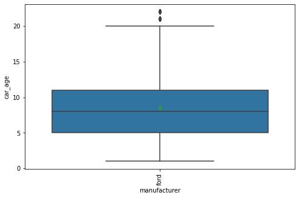

```python
# Draw a boxplot for car_age again to make sure the outliers are gone
plt.figure(figsize=(8,5))
sns.boxplot(x='manufacturer', y='car_age', data=vehicles5, showmeans=True)
plt.xticks(rotation=90)
plt.show()
```

### Linear Regression Model

```python
model_prepared = full_pipeline.fit_transform(vehicles5)
```

```python
model_labels = vehicles5.price
```

```python
lin_reg = LinearRegression()
lin_reg.fit(model_prepared, model_labels)
```

```
LinearRegression()
```

```python
price_predictions_model = lin_reg.predict(model_prepared)
```

```python
lin_mse = mean_squared_error(model_labels, price_predictions_model)
lin_rmse = np.sqrt(lin_mse)
print("RMSE of the linear regression price predictions for the vehicles5 data set: %.0f" % lin_rmse)
```

```
RMSE of the linear regression price predictions for the vehicles5 data set: 7170
```

```python
print(lin_rmse/(vehicles5.price.median()))
```

```
0.2988881348269688
```

### Random Forest Regressor with Grid Search CV

```python
param_grid = [
{'n_estimators': [3, 10, 30], 'max_features': [2, 4, 6, 8]},
{'bootstrap': [False], 'n_estimators': [3, 10], 'max_features': [2, 3, 4]},
]

forest_reg_model = RandomForestRegressor()

grid_search_model = GridSearchCV(forest_reg_model, param_grid, cv=5, scoring='neg_mean_squared_error', return_train_score=True)

grid_search_model.fit(model_prepared, model_labels)
```

```
GridSearchCV(cv=5, estimator=RandomForestRegressor(),
             param_grid=[{'max_features': [2, 4, 6, 8],
                          'n_estimators': [3, 10, 30]},
                         {'bootstrap': [False], 'max_features': [2, 3, 4],
                          'n_estimators': [3, 10]}],
             return_train_score=True, scoring='neg_mean_squared_error')
```

```python
grid_search_model.best_params_
```

```
{'max_features': 8, 'n_estimators': 30}
```

```python
grid_search.best_estimator_
```

```
RandomForestRegressor(max_features=8, n_estimators=30)
```

```python
cv_results = grid_search.cv_results_
```

```python
for mean_score, params in zip(cv_results["mean_test_score"], cv_results["params"]):
    print(np.sqrt(-mean_score),'  ', np.sqrt(-mean_score)/vehicles5.price.median(),' ', params)
```

```
8130.974210367224    0.3389318136876709   {'max_features': 2, 'n_estimators': 3}
7312.058836862509    0.3047961165845148   {'max_features': 2, 'n_estimators': 10}
6927.488208568886    0.2887656610491407   {'max_features': 2, 'n_estimators': 30}
7853.977530916049    0.3273854744025031   {'max_features': 4, 'n_estimators': 3}
7138.835264219785    0.2975754591171232   {'max_features': 4, 'n_estimators': 10}
6836.563183772283    0.2849755391318167   {'max_features': 4, 'n_estimators': 30}
7680.3768969969515    0.3201490994996645   {'max_features': 6, 'n_estimators': 3}
7006.522775438272    0.2920601407018871   {'max_features': 6, 'n_estimators': 10}
6745.757097708801    0.2811903750608087   {'max_features': 6, 'n_estimators': 30}
7524.960782451974    0.31367072873914026   {'max_features': 8, 'n_estimators': 3}
6964.248854775514    0.2902979931127767   {'max_features': 8, 'n_estimators': 10}
6698.108440442247    0.27920418676291153   {'max_features': 8, 'n_estimators': 30}
7974.345396418558    0.3324028927227411   {'bootstrap': False, 'max_features': 2, 'n_estimators': 3}
7227.746119347033    0.30128162231542444   {'bootstrap': False, 'max_features': 2, 'n_estimators': 10}
7933.333096093701    0.33069333455997085   {'bootstrap': False, 'max_features': 3, 'n_estimators': 3}
7113.285858639679    0.29651045680032007   {'bootstrap': False, 'max_features': 3, 'n_estimators': 10}
7791.846350764919    0.32479559611358566   {'bootstrap': False, 'max_features': 4, 'n_estimators': 3}
7062.5306581154655    0.29439477524449625   {'bootstrap': False, 'max_features': 4, 'n_estimators': 10}
```

# Conclusion

Despite our best efforts, we weren't able to achieve good values of the RMSE in any of the models we built (the best value of RMSE we were able to achieve was 0.28). Like we mentioned before, this underlines the difficulty in building regression models for data sets that have many categorical variables and fewer numerical variables. More work is necessary to drill down the data even further and try to achieve better predictive results. One possibility is to try to use the OLS class from the statsmodels.api package to try to better understand how the different categories affect the regression estimates. This will be the subject of a future project.